# R Basics/Visualization

The following are some basic R code. The list is not entensive, nor is it a best pratice list The first is concatinating. This allows you to create a variable term that includes multiple values

```r
?c
x<-c(1, 3, 2, 5)
x
```

```
[1] 1 3 2 5
```

To save a variable, we will use = instead of < or >

```r
x = c(1, 6, 2)
x
```

```
[1] 1 6 2
```

```r
y = c(1 ,4 ,3)
y
```

```
[1] 1 4 3
```

Next we will add numbers together The length function tells us how many terms are concatinated in our variable

```r
length(x)
```

```
[1] 3
```

```r
x+y
```

```
[1]  2 10  5
```

#By adding these two variables, R will go through and add each corresponding term together. X1+y1…

#The ls() function allows us to look at a list of all objects, such as data and functions, that we have saved so far. The rm() function can be used to delete any we dont want.

```r
ls()
```

```
[1] "A"  "f"  "fa" "x"  "y"
```

```r
rm(x,y)
ls()
```

```
[1] "A"  "f"  "fa"
```

```r
rm(list=ls())
```

#The matrix() function can be used to create a matrix

```r
?matrix
x=matrix(data=c(1, 2, 3, 4), nrow=2, ncol=2)
x
```

```
     [,1] [,2]
[1,]    1    3
[2,]    2    4
```

```r
matrix(c(1, 2, 3, 4), 2, 2, byrow=TRUE)
```

```
     [,1] [,2]
[1,]    1    2
[2,]    3    4
```

#As you can see through this exaple, R, by default, fills out a matrix by successfully filling in columns. We can change the default by using byrow

#The sqrt() function returns the sqauare element of a vector or matrix. The command x^2 raises each element of x to the power of 2.

```r
sqrt(x)
```

```
         [,1]     [,2]
[1,] 1.000000 1.732051
[2,] 1.414214 2.000000
```

```r
x
```

```
     [,1] [,2]
[1,]    1    3
[2,]    2    4
```

```r
x^2
```

```
     [,1] [,2]
[1,]    1    9
[2,]    4   16
```

```r
x
```

```
     [,1] [,2]
[1,]    1    3
[2,]    2    4
```

#The rnorm() function generates a vector of random normal variable, with the first argument, n, the sample size. Each time we call this function, we will get a different answer.Here we will create an x and y variable and then use cor() function to compute the correlation.

```r
x=rnorm(50)
y=x+rnorm(50, mean=50, sd=0.1)
cor(x,y)
```

```
[1] 0.9953204
```

#We typically want to be able to reproduce our results, so we use the function set.seed() so that R will produce the same random numbers each time the code is run.

```r
set.seed(1303)
rnorm(7)
```

```
[1] -1.1439763145  1.3421293656  2.1853904757  0.5363925179  0.0631929665
[6]  0.5022344825 -0.0004167247
```

```r
set.seed(3)
y=rnorm(100)
mean(y)
```

```
[1] 0.01103557
```

```r
var(y)
```

```
[1] 0.7328675
```

```r
sqrt(var(y))
```

```
[1] 0.8560768
```

```r
sd(y)
```

```
[1] 0.8560768
```

#The next part of this code will focus on graphs and visualizing data…

#The plot function is the basic way to plot in data.

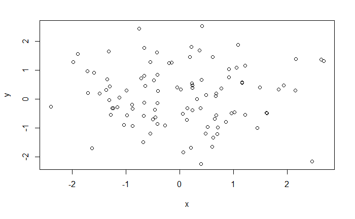

```r
x=rnorm(100)
y=rnorm(100)
plot(x,y)
```

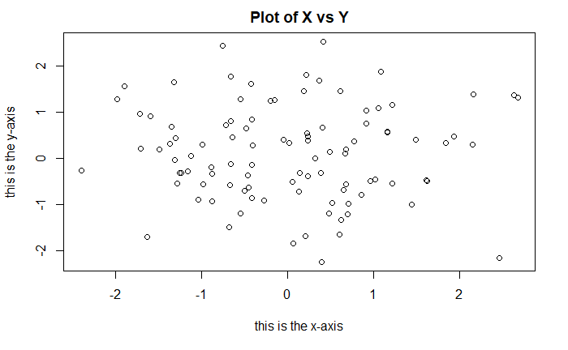

```r
plot(x,y,xlab="this is the x-axis", ylab="this is the y-axis", main="Plot of X vs Y")
```

#We often want to save the output of an R plot. The command you’ll use will depend on the format or file type that you want to create. We can use the pdf() or jpeg() functions.

```r
pdf("Figure.pdf")
plot(x, y, col="green")
dev.off()
```

#dev.off indicates to R that we are done creating the plot. #The function seq() can be used to create a sequence of numbers.

```r
x=seq(1,10)
x
```

```
 [1]  1  2  3  4  5  6  7  8  9 10
```

```r
x=1:10
x
```

```
 [1]  1  2  3  4  5  6  7  8  9 10
```

```r
x=seq(-pi,pi,length=7)
x
```

```
[1] -3.141593 -2.094395 -1.047198  0.000000  1.047198  2.094395  3.141593
```

#More sophisticated plots use the contour() function. We need three dimensions here.

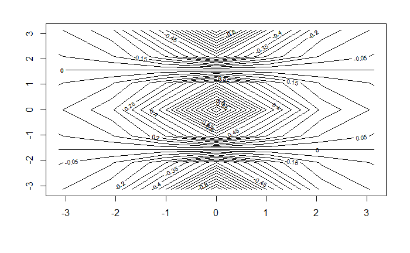

```r
?contour
y=x
f=outer(x,y,function(x,y)cos(y)/(1+x^2))
  contour(x,y,f)
  contour(x,y,f,nlevels=45,add=T)
```

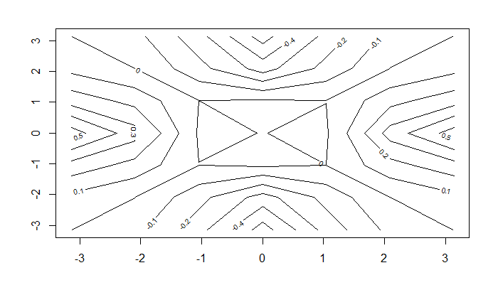

```r
fa=(f-t(f))/2
contour(x,y,fa,nlevels=15)
```

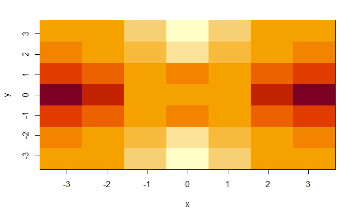

```r
image(x,y,fa)
```

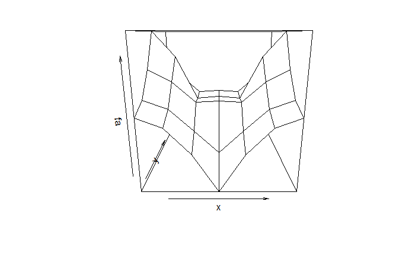

```r
persp(x,y,fa)
```

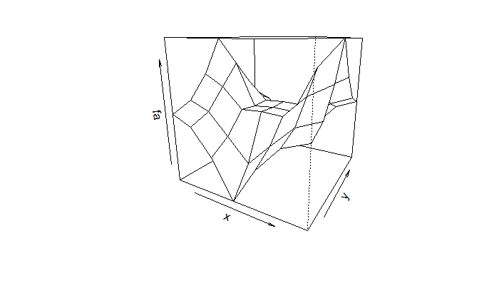

```r
persp(x,y,fa,theta=30)
```

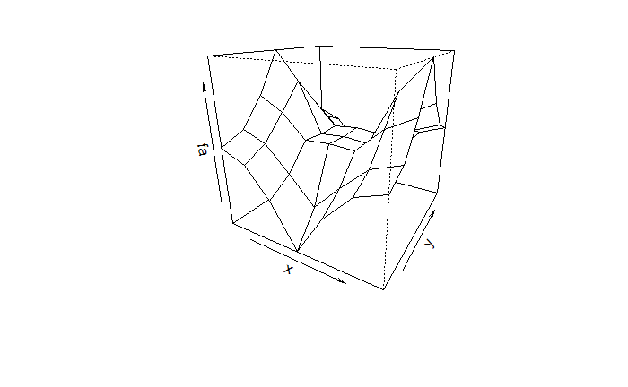

```r
persp(x,y,fa,theta=30, phi=20)
```

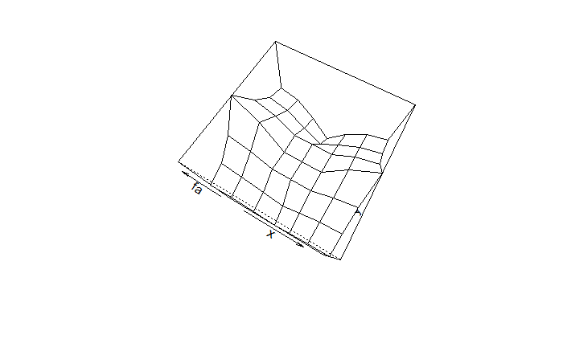

```r
persp(x,y,fa,theta=30, phi=70)
```

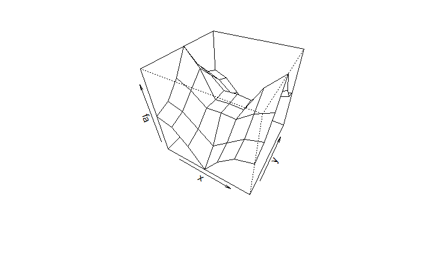

```r
persp(x,y,fa,theta=30, phi=40)
```

#Indexing Data.

##We often wasnt to examine a part of a set of data. R will recognize the components of a matrix using the ith row, jth column element.

```r
A=matrix(1:16,4,4)
A
```

```
     [,1] [,2] [,3] [,4]
[1,]    1    5    9   13
[2,]    2    6   10   14
[3,]    3    7   11   15
[4,]    4    8   12   16
```

```r
A[2,3]
```

```
[1] 10
```

```r
A[c(1,3),c(2,4)]
```

```
     [,1] [,2]
[1,]    5   13
[2,]    7   15
```

```r
A[1:3,2:4]
```

```
     [,1] [,2] [,3]
[1,]    5    9   13
[2,]    6   10   14
[3,]    7   11   15
```

```r
A[1:2,]
```

```
     [,1] [,2] [,3] [,4]
[1,]    1    5    9   13
[2,]    2    6   10   14
```

```r
A[,1:2]
```

```
     [,1] [,2]
[1,]    1    5
[2,]    2    6
[3,]    3    7
[4,]    4    8
```

```r
A[1,]
```

```
[1]  1  5  9 13
```

```r
A[-c(1,3),]
```

```
     [,1] [,2] [,3] [,4]
[1,]    2    6   10   14
[2,]    4    8   12   16
```

```r
A[-c(1,3),-c(1,3,4)]
```

```
[1] 6 8
```

```r
dim(A)
```

```
[1] 4 4
```